# c_mulvey_r_solo

```r
library(tidyverse)
library(readxl)
```

1.Read in districts.csv into a tibble named districts. How many rows and columns does it contain?

```r
districts <- read_csv('../data/districts.csv')
```

There are 146 rows and 27 columns.

2.Notice that the first row corresponds to the whole State of Tennessee. Remove this row and save the result back to districts.

```r
districts <- districts[-1,]
```

3. How many districts have a proficiency rate of at least 80% for both alg_1 and eng_1?

```r
districts %>%
  filter(alg_1 > 80 & eng_1 > 80) %>%
  count()
```

| n |
| --- |
| 13 |

4. How many districts have a proficiency rate less than 50% for either alg_1 or eng_1?

```r
districts %>%
  filter(alg_1 < 50 | eng_1 < 50) %>%
  count()
```

| n |
| --- |
| 8 |

5. Which district has the lowest graduation rate?

```r
districts %>%
  filter(grad == min(grad, na.rm = TRUE))
```

| system | system_name | alg_1 | alg_2 | bio | chem | ela | eng_1 | eng_2 | eng_3 | math | science | enrollment | black | hispanic | native | el | swd | ed | expenditures | act_composite | chronic_abs | suspended | expelled | grad | dropout | region |
| --- | --- | --- | --- | --- | --- | --- | --- | --- | --- | --- | --- | --- | --- | --- | --- | --- | --- | --- | --- | --- | --- | --- | --- | --- | --- | --- |
| 963 | Tenn School for Blind | 23.1 | NA | 25 | NA | 6.7 | 60 | NA | 20 | NA | 10 | NA | 16.1 | 9.8 | 0 | 1.4 | 94.4 | 32.9 | NA | NA | 41.3 | 0 | 0 | 11.1 | 0 | Mid Cumberland |

6. Which district has the highest dropout rate?

```r
districts %>%
  filter(dropout == max(dropout, na.rm = TRUE))
```

| system | system_name | alg_1 | alg_2 | bio | chem | ela | eng_1 | eng_2 | eng_3 | math | science | enrollment | black | hispanic | native | el | swd | ed | expenditures | act_composite | chronic_abs | suspended | expelled | grad | dropout | region |
| --- | --- | --- | --- | --- | --- | --- | --- | --- | --- | --- | --- | --- | --- | --- | --- | --- | --- | --- | --- | --- | --- | --- | --- | --- | --- | --- |
| 985 | Achievement School District | 34 | 20.4 | 20.6 | NA | 14.3 | 37.8 | 33 | 8.2 | 23.3 | 26.1 | 6370 | 96.7 | 1.5 | 0 | 1.1 | 12.9 | 96.6 | 12804.4 | 14.2 | 27.2 | 21.4 | 0.1 | 54.7 | 27.6 | Southwest/Memphis |

7. Within the Mid Cumberland region, which district has the highest ACT composite?

```r
districts %>%
  filter(region == 'Mid Cumberland') %>%
  filter(act_composite == max(act_composite, na.rm = TRUE))
```

| system | system_name | alg_1 | alg_2 | bio | chem | ela | eng_1 | eng_2 | eng_3 | math | science | enrollment | black | hispanic | native | el | swd | ed | expenditures | act_composite | chronic_abs | suspended | expelled | grad | dropout | region |
| --- | --- | --- | --- | --- | --- | --- | --- | --- | --- | --- | --- | --- | --- | --- | --- | --- | --- | --- | --- | --- | --- | --- | --- | --- | --- | --- |
| 940 | Williamson County | 90.3 | 84.8 | 89.2 | 81 | 80.7 | 92.9 | 88.7 | 68.6 | 80.3 | 91.1 | 34395 | 5 | 5.3 | 0.7 | 1.7 | 10.2 | 9.6 | 8739.7 | 23.8 | 7 | 0.2 | 0 | 94.4 | 4.4 | Mid Cumberland |

8. Create a histogram showing the distribution of graduation rates. What can you say about this distribution?

```
Warning: Removed 17 rows containing non-finite values (stat_bin).
```

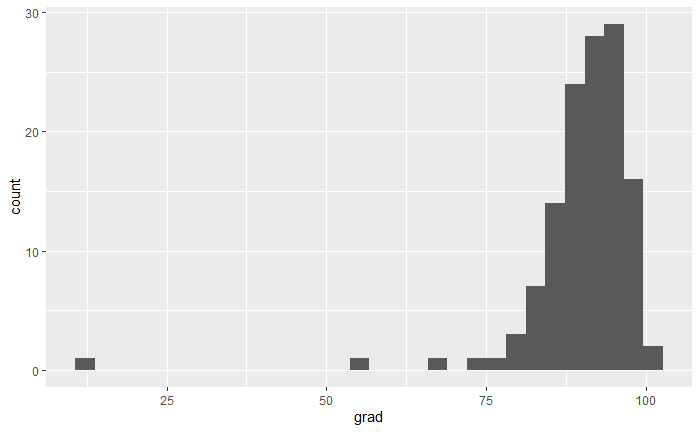

```r
districts %>%
  ggplot(aes(x = grad)) +
  geom_histogram()
```

The distribution is left skewed.

9. Create a scatter plot to compare alg_1 proficiency rates to alg_2 rates. What do you notice? Facet this plot by region. Does anything stand out when you facet the plots?

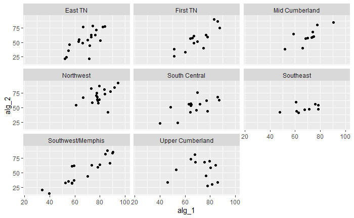

```r
districts %>%
  ggplot(aes(x = alg_1, y = alg_2)) +
  geom_point() +
  facet_wrap(~ region)
```

10. Create a bar chart showing the total enrollment by region. Which region has the highest total enrollment? Which has the smallest?

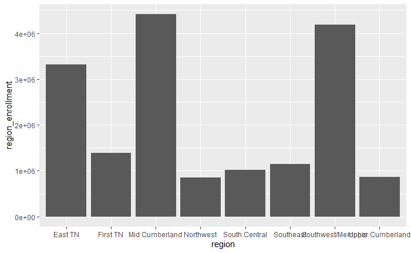

```r
districts %>%
  group_by(region) %>%
  mutate(region_enrollment = sum(enrollment, na.rm = TRUE)) %>%
  ggplot(aes(x = region,  y = region_enrollment)) +
  geom_col()
```

Mid Cumberland has the highest enrollment and Northwest has the smallest.

11.When creating this bar chart you may have noticed that some districts have missing enrollment values. For how many districts is this the case?

```r
districts %>%
  filter(is.na(enrollment)) %>%
  count()
```

| n |
| --- |
| 4 |

12. What is the mean graduation rate across all districts? What might be wrong with using just the regular mean to assess average graduation rates?

```r
districts %>%
  summarize(mean(grad, na.rm = TRUE))
```

| mean(grad, na.rm = TRUE) |
| --- |
| 90.06562 |

# 13. Redo the previous question but use a weighted average (weighted.mean) graduation across all districts, weighing by enrollment. How much does this change your answer? Can you explain using the data the reason for the big change from using the mean?

```r
districts %>%
  drop_na(c(grad, enrollment)) %>%
  summarize(weighted.mean(grad, enrollment, na.rm = TRUE))
```

| weighted.mean(grad, enrollment, na.rm = TRUE) |
| --- |
| 87.33285 |

14. Create a boxplot showing enrollment rates per region. Does anything stand out?

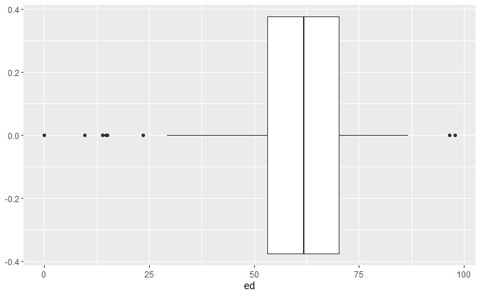

```r
districts %>%
  group_by(region) %>%
  ggplot(aes(x = ed)) +
  geom_boxplot()
```

15. Create a boxplot showing graduation rates per region. Does anything stand out?

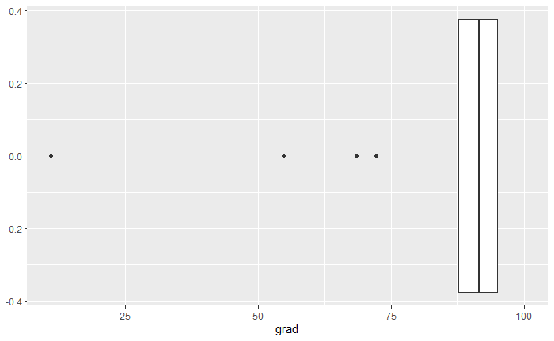

```r
districts %>%
  group_by(region) %>%
  ggplot(aes(x = grad)) +
  geom_boxplot()
```

16. Find the weighted average of graduation rates by region using enrollment as weights. Compare the results you get for the weighted average to what you see from the boxplots. Can you explain any discrepancy?

```r
districts %>%
  group_by(region) %>%
  summarize(weighted.mean(grad, enrollment, na.rm = TRUE))
```

| region | weighted.mean(grad, enrollment, na.rm = TRUE) |
| --- | --- |
| East TN | NA |
| First TN | 91.91454 |
| Mid Cumberland | NA |
| Northwest | 91.57705 |
| South Central | 90.47392 |
| Southeast | 85.95494 |
| Southwest/Memphis | 79.45971 |
| Upper Cumberland | NA |

There are three regions that don’t have a weighted mean.

17. For many districts, values for alg_2 are lower than for alg_1. Create a histogram showing the distribution of differences (alg_1 - alg_2). Which school had the largest drop from alg_1 to alg_2? For what percentage of schools is it true that alg_2 is larger than alg_1? Is there a similar dropoff for eng_2 and eng_3?

```
Warning: Removed 28 rows containing non-finite values (stat_bin).
```

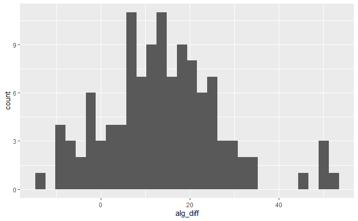

```r
districts %>%
  mutate(alg_diff = alg_1 - alg_2) %>%
  ggplot(aes(x = alg_diff)) +
  geom_histogram()
```

```r
districts %>%
  mutate(alg_diff = alg_1 - alg_2) %>%
  filter(alg_diff < 0) %>%
  filter(alg_diff == min(alg_diff))
```

| system | system_name | alg_1 | alg_2 | bio | chem | ela | eng_1 | eng_2 | eng_3 | math | science | enrollment | black | hispanic | native | el | swd | ed | expenditures | act_composite | chronic_abs | suspended | expelled | grad | dropout | region | alg_diff |
| --- | --- | --- | --- | --- | --- | --- | --- | --- | --- | --- | --- | --- | --- | --- | --- | --- | --- | --- | --- | --- | --- | --- | --- | --- | --- | --- | --- |
| 140 | Clay County | 68 | 81.4 | 65.8 | 31.8 | 33.5 | 60 | 57.9 | 35.9 | 40 | 54 | 1024 | 1.8 | 2.1 | 0.3 | 0.3 | 16.2 | 70.7 | 9237.5 | 18.4 | 9.8 | 0.5 | 0 | 96.8 | 1.6 | Upper Cumberland | -13.4 |

```r
greater <- districts %>%
  mutate(alg_diff = alg_1 - alg_2) %>%
  filter(alg_diff > 0) %>%
  count()


 greater / count(districts) * 100
```

| n |
| --- |
| 68.27586 |

```
Warning: Removed 19 rows containing non-finite values (stat_bin).
```

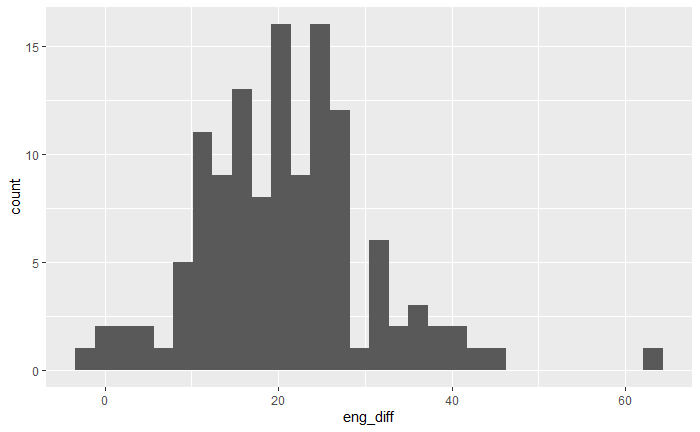

```r
districts %>%
  mutate(eng_diff = eng_2 - eng_3) %>%
  ggplot(aes(x = eng_diff)) +
  geom_histogram()
```

```r
districts %>%
  mutate(eng_diff = eng_2 - eng_3) %>%
  filter(eng_diff < 0) %>%
  filter(eng_diff == min(eng_diff))
```

| system | system_name | alg_1 | alg_2 | bio | chem | ela | eng_1 | eng_2 | eng_3 | math | science | enrollment | black | hispanic | native | el | swd | ed | expenditures | act_composite | chronic_abs | suspended | expelled | grad | dropout | region | eng_diff |
| --- | --- | --- | --- | --- | --- | --- | --- | --- | --- | --- | --- | --- | --- | --- | --- | --- | --- | --- | --- | --- | --- | --- | --- | --- | --- | --- | --- |
| 274 | Bradford SSD | 94.4 | 92.6 | 87.9 | 66.7 | 56.5 | 81.8 | 68.4 | 70.4 | 73.4 | 75.4 | 499 | 6.1 | 0.6 | 0 | 0 | 17.3 | 62.8 | 10143.5 | 18.7 | 11.4 | 0.9 | 0 | 100 | 0 | Northwest | -2 |

```r
districts %>%
  mutate(eng_diff = eng_2 - eng_3) %>%
  filter(eng_diff < 0) %>%
  count()
```

| n |
| --- |
| 1 |

```r
greater <- districts %>%
  mutate(eng_diff = eng_2 - eng_3) %>%
  filter(eng_diff > 0) %>%
  count()


 greater / count(districts) * 100
```

| n |
| --- |
| 86.2069 |

18. You may have noticed that a lot of rows are missing values. Which district has the largest number of missing values? What do you notice about schools that have a lot of missing values?

```r
districts %>%
  filter_all(any_vars( is.na(.)))
```

| system | system_name | alg_1 | alg_2 | bio | chem | ela | eng_1 | eng_2 | eng_3 | math | science | enrollment | black | hispanic | native | el | swd | ed | expenditures | act_composite | chronic_abs | suspended | expelled | grad | dropout | region |
| --- | --- | --- | --- | --- | --- | --- | --- | --- | --- | --- | --- | --- | --- | --- | --- | --- | --- | --- | --- | --- | --- | --- | --- | --- | --- | --- |
| 11 | Clinton City | NA | NA | NA | NA | 58.3 | NA | NA | NA | 68.9 | 69.6 | 894 | 5.7 | 2.8 | 0.3 | 1.0 | 18.1 | 63.4 | 9537.5 | NA | 8.8 | 1.2 | 0.0 | NA | NA | East TN |
| 60 | Bradley County | NA | 59.5 | 64.1 | 55.7 | 52.4 | 74.4 | 66.3 | 38.2 | 57.1 | 65.9 | 9801 | 3.6 | 4.3 | 0.3 | 1.6 | 11.3 | 55.1 | 8429.3 | 18.8 | 16.0 | 3.9 | 0.1 | 93.1 | 5.6 | Southeast |
| 80 | Cannon County | NA | 52.5 | 66.9 | 26.0 | 45.1 | 65.7 | 61.2 | 23.8 | 49.8 | 62.9 | 1944 | 1.7 | 2.3 | 0.3 | 0.5 | 16.2 | 55.3 | 8401.6 | 18.6 | 14.5 | 1.7 | 0.0 | 95.1 | 2.1 | Upper Cumberland |
| 100 | Carter County | NA | NA | 70.3 | 23.5 | 40.4 | 69.0 | 68.9 | 43.1 | 46.8 | 64.1 | 5162 | 1.5 | 1.9 | 0.6 | 0.5 | 17.0 | 76.6 | 9133.9 | 18.3 | 16.9 | 3.1 | 0.0 | 88.6 | 8.0 | First TN |
| 110 | Cheatham County | NA | NA | 73.3 | 53.1 | 46.4 | 75.5 | 57.7 | 47.9 | 55.7 | 66.4 | 6240 | 2.6 | 3.6 | 0.4 | 1.1 | 15.3 | 49.1 | 8412.6 | 20.8 | 13.4 | 5.8 | 0.1 | 91.2 | 5.9 | Mid Cumberland |
| 151 | Newport City | NA | NA | NA | NA | 56.9 | NA | NA | NA | 55.3 | 84.6 | 717 | 7.1 | 3.0 | 0.5 | 0.8 | 14.4 | 58.0 | 9216.2 | NA | 11.8 | 0.1 | 0.0 | NA | NA | First TN |
| 161 | Manchester City | NA | NA | NA | NA | 53.6 | NA | NA | NA | 59.0 | 71.8 | 1211 | 5.8 | 14.6 | 0.5 | 10.0 | 20.9 | 23.6 | 12309.4 | NA | 10.2 | 0.4 | 0.0 | NA | NA | South Central |
| 171 | Alamo City | NA | NA | NA | NA | 53.5 | NA | NA | NA | 62.8 | 74.6 | 578 | 11.6 | 16.7 | 0.0 | 1.1 | 11.4 | 69.9 | 8669.4 | NA | 7.8 | 0.2 | 0.0 | NA | NA | Northwest |
| 172 | Bells City | NA | NA | NA | NA | 60.8 | NA | NA | NA | 60.8 | 79.5 | 365 | 16.3 | 21.0 | 0.0 | 13.2 | 13.2 | 74.1 | 8817.6 | NA | 3.2 | 0.2 | 0.0 | NA | NA | Northwest |
| 271 | Humboldt City | 86.2 | 41.7 | 35.9 | NA | 26.6 | 53.1 | 41.4 | 19.0 | 38.4 | 43.8 | 1018 | 75.3 | 4.3 | 0.2 | 2.3 | 16.3 | 97.9 | 11121.5 | 15.9 | 17.4 | 0.4 | 0.1 | 68.5 | 20.2 | Northwest |

[output cut: 23 more lines]

19. Find the correlation between graduation rate and all other variables. Create a horizontal bar chart showing these correlations. Make sure that your plot is ordered by correlation values. What do you notice from these correlations?

```r
districts %>%
  select(where(is.numeric)) %>%
  cor(use = 'pairwise.complete.obs') %>%
  .[24,]
```

```
       system         alg_1         alg_2           bio          chem           ela         eng_1         eng_2         eng_3          math
  -0.21637680    0.44239636    0.39558968    0.51740538    0.24560709    0.51383863    0.38067993    0.46423032    0.42942393    0.40670215
      science    enrollment         black      hispanic        native            el           swd            ed  expenditures act_composite
   0.61291387   -0.30108493   -0.40798847   -0.17747659    0.12466259   -0.13532742   -0.55552703   -0.06139009   -0.42661800    0.35843967
  chronic_abs     suspended      expelled          grad       dropout
  -0.51492981   -0.28196098   -0.16041908    1.00000000   -0.50389017
```

20. Create a scatterplot for grad vs. suspended. Does what you see make sense given your answer from the previous part?

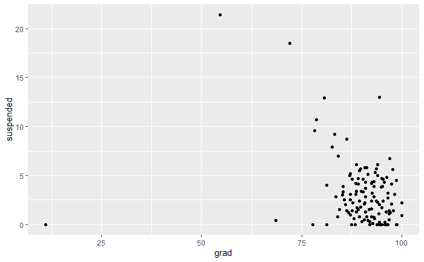

```r
districts %>%
  ggplot(aes(x = grad, y= suspended)) +
  geom_point()
```

21. Create a linear regression model using lm with target variable grad and predictor variable suspended. What R^2 value does this model have? What is the interpretation of this number?

```r
grad_suspended_model <- lm(grad ~ suspended, data = districts)

summary(grad_suspended_model)
```

```
Call:
lm(formula = grad ~ suspended, data = districts)

Residuals:
    Min      1Q  Median      3Q     Max
-81.407  -2.271   1.190   3.934  12.208

Coefficients:
            Estimate Std. Error t value Pr(>|t|)
(Intercept)  92.5071     1.0924  84.679  < 2e-16 ***
suspended    -0.7858     0.2382  -3.299  0.00126 **
---
Signif. codes:  0 ‘***’ 0.001 ‘**’ 0.01 ‘*’ 0.05 ‘.’ 0.1 ‘ ’ 1

Residual standard error: 9.091 on 126 degrees of freedom
  (17 observations deleted due to missingness)
Multiple R-squared:  0.0795,    Adjusted R-squared:  0.0722
F-statistic: 10.88 on 1 and 126 DF,  p-value: 0.001262
```

22. Add the regression line to your scatterplot using geom_smooth with method=‘lm’. How do you feel about the regression line after seeing it plotted on the scatterplot?

```
Warning: Removed 17 rows containing non-finite values (stat_smooth).
```

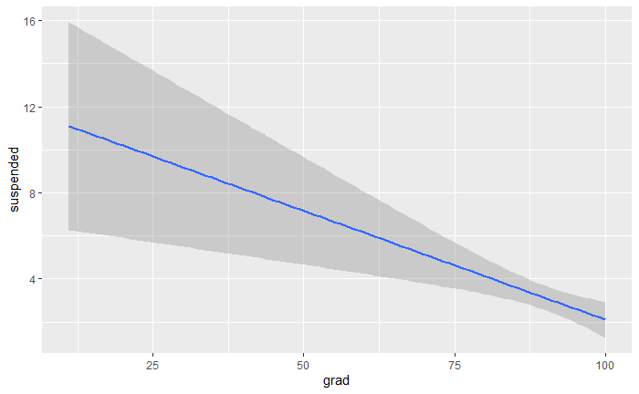

```r
districts %>%
  ggplot(aes(x = grad, y= suspended)) +
  geom_smooth(method = 'lm')
```

Continued Exploration and Practice

23. Read in the school-level testing data for 2014, available here. You might find the readxl library useful for this task. If you use this library, be sure to look at the na argument for the read_excel function.

```r
testing <- read_excel('../data/data_2014_school_base.xlsx',
                      na = c('*', '**'))
```

24. How many schools have at least 20 percent of students below bsc for Algebra I? Which districts do these schools belong to?

```r
testing %>%
  group_by(subject) %>%
  filter(subgroup == 'All Students' &
           grade == 'All Grades' &
           subject == 'Algebra I' &
           pct_below_bsc >= 20) %>%
  count()
```

| subject | n |
| --- | --- |
| Algebra I | 71 |

```r
testing %>%
  group_by(subject) %>%
  filter(subgroup == 'All Students' &
           grade == 'All Grades' &
           subject == 'Algebra I' &
           pct_below_bsc >= 20) %>%
  select(system_name) %>%
  unique()
```

| subject | system_name |
| --- | --- |
| Algebra I | Bedford County |
| Algebra I | Bledsoe County |
| Algebra I | Maryville |
| Algebra I | Bradley County |
| Algebra I | Campbell County |
| Algebra I | Hollow Rock-Bruceton |
| Algebra I | Cheatham County |
| Algebra I | Claiborne County |
| Algebra I | Cumberland County |
| Algebra I | Davidson County |

[output cut: 20 more lines]

24. How many schools have at least 20 percent of students below bsc for both Algebra I and English I?

```r
testing %>%
  filter(subgroup == 'All Students' &
           grade == 'All Grades') %>%
  filter(subject == 'Algebra I' &
           pct_below_bsc >= 20 |
           subject == 'English I' &
           pct_below_bsc >= 20) %>%
  count()
```

| n |
| --- |
| 79 |

```r
NA
```